# updated_coding_comments

Lisa Pardee

2025-05-02

#——————————————————

1. Loading and Visualizaing the Real Data from Villaroig et al. #——————————————————

```r
real_data = read_csv("modeling_data.csv") %>%
  complete(week = 0:36, fill = list(
    reported_cases = 0,
    unvaccinated_cases = 0,
    vaccinated_cases = 0,
    vaccination_rate = 0
  ))
```

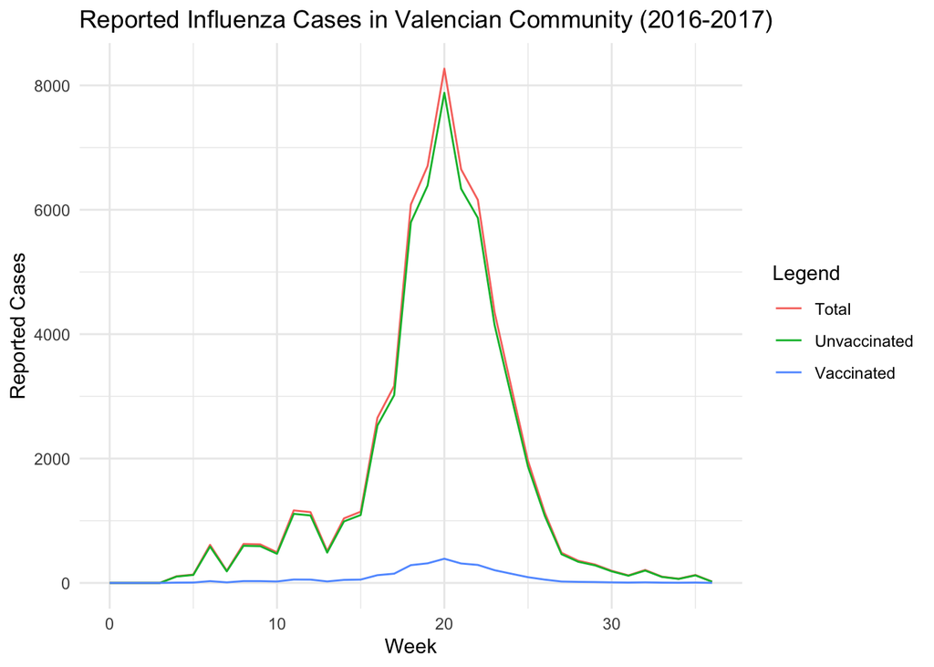

```r
# Plot reported cases
ggplot(real_data, aes(x = week)) +
  geom_line(aes(y = reported_cases, color = "Total")) +
  geom_line(aes(y = unvaccinated_cases, color = "Unvaccinated")) +
  geom_line(aes(y = vaccinated_cases, color = "Vaccinated")) +
  labs(title = "Reported Influenza Cases in Valencian Community (2016-2017)",
       x = "Week", y = "Reported Cases", color = "Legend") +
  theme_minimal()
```

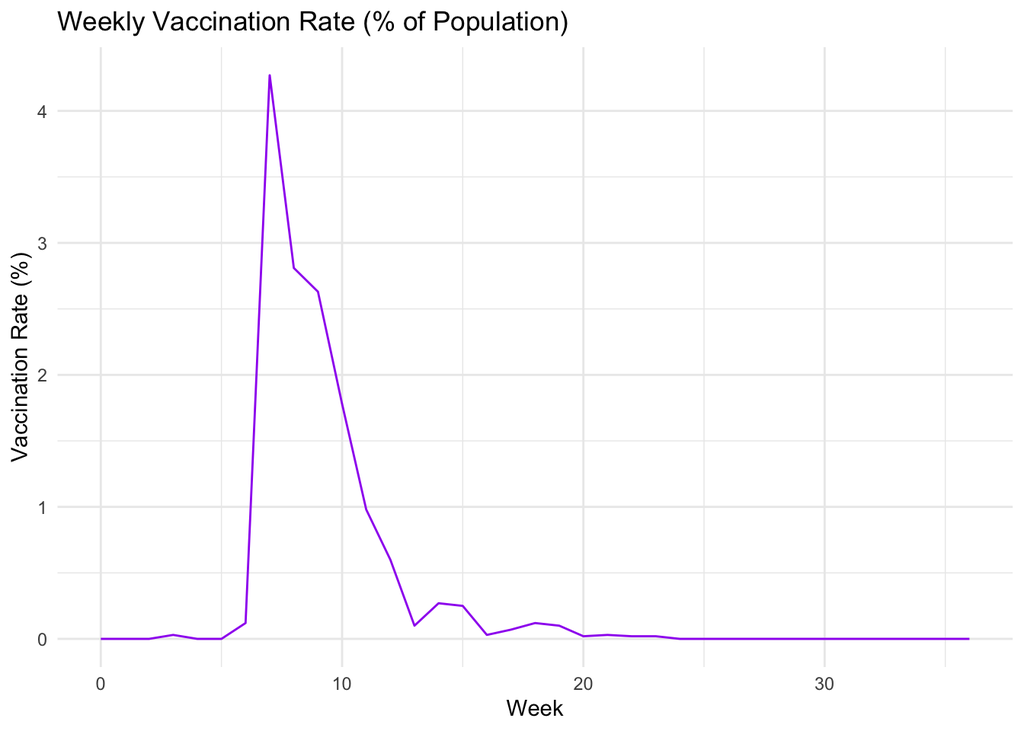

```r
# Plot vaccination rate
ggplot(real_data, aes(x = week, y = vaccination_rate)) +
  geom_line(color = "purple") +
  labs(title = "Weekly Vaccination Rate (% of Population)",
       x = "Week", y = "Vaccination Rate (%)") +
  theme_minimal()
```

#——————————————————

2. Setting Parameters and the Vaccination Function (NOTE: i.e., the original paper did not incorporate a time-dependent proportion. We did so for our paper because we wanted to simulate the vaccination campaign which the original paper did not do) #——————————————————

```r
N <- 4959968
beta = 9.1357
lambda <- 3.5
gamma <- 1
report_rate <- 0.0702
times <- seq(0, 36, by = 1)

# Vaccination function
d_vector <- real_data$vaccination_rate / 100
d_func <- approxfun(x = times, y = d_vector, rule = 2)
```

#——————————————————

3. Constructing the SEIR Model NOTE: a deviation from the original code is that after research, we incorporated seeding into our model because the paper noted that influenza cases were probably already spreading prior to surveillance. So while the paper itself incorporated an additional 4 weeks before the data started (as noted in class) we decided to do this through seeding. We tried different values of seeding to initiate transmission. This aided in proper alignment with the real world data. All differential equtions were obtained from Villaroig. #——————————————————

```r
seir_model <- function(t, state, parameters) {
  with(as.list(c(state, parameters)), {
    if (t >= 3 & t < 3.1) {
      Iu <- Iu + 300
      Lu <- Lu + 700
      Su <- Su - 1000
    }

    I_total <- Iu + Iv
    dSu <- -beta * Su * I_total / N - d_func(t) * Su
    dSv <- -a_v * beta * Sv * I_total / N + d_func(t) * Su
    dLu <- beta * Su * I_total / N - lambda * Lu
    dLv <- a_v * beta * Sv * I_total / N - lambda * Lv
    dIu <- lambda * Lu - gamma * Iu
    dIv <- lambda * Lv - gamma * Iv
    dRu <- gamma * Iu - d_func(t) * Ru
    dRv <- gamma * Iv + d_func(t) * Ru
    dCumIncU <- lambda * Lu
    dCumIncV <- lambda * Lv

    return(list(c(dSu, dSv, dLu, dLv, dIu, dIv, dRu, dRv, dCumIncU, dCumIncV)))
  })
}
```

#——————————————————

4. Used a cost function to evaluate the model fit. Villaroig tested different parameters for beta, vaccine attenuation facotr (av), and R0. #——————————————————

```r
cost_function <- function(par) {
  beta <- par[1]
  a_v <- par[2]
  R0_prop <- par[3]
  R0 <- R0_prop * N

  init <- c(
    Su = N - R0, Sv = 0,
    Lu = 0, Lv = 0,
    Iu = 0, Iv = 0,
    Ru = R0, Rv = 0,
    CumIncU = 0, CumIncV = 0
  )

  out <- ode(y = init, times = times, func = seir_model, parms = list(beta = beta, a_v = a_v))
  out_df <- as.data.frame(out)

  out_df <- out_df %>%
    mutate(week = time,
           new_inf_unvacc = c(NA, diff(CumIncU)),
           new_inf_vacc = c(NA, diff(CumIncV))) %>%
    filter(!is.na(new_inf_unvacc)) %>%
    mutate(
      reported_unvacc = new_inf_unvacc * report_rate,
      reported_vacc = new_inf_vacc * report_rate
    )

  merged <- left_join(real_data, out_df, by = "week")

  sse <- sum((merged$unvaccinated_cases - merged$reported_unvacc)^2, na.rm = TRUE) +
    sum((merged$vaccinated_cases - merged$reported_vacc)^2, na.rm = TRUE)

  return(sse)
}
```

#——————————————————

5. Performed optimization. The values for the initial guess are based on a table provided by Villaroig et al. that determined ideal ranges for optimal calibration. these values for beta, av, and R0 were in the range of optimal values #——————————————————

```r
initial_guess <- c(9, 0.24, 0.77)

fit <- optim(par = initial_guess, fn = cost_function,
             method = "L-BFGS-B",
             lower = c(0.1, 0.01, 0.01),
             upper = c(15, 1, 1))

best_params <- fit$par
beta <- best_params[1]
a_v <- best_params[2]
R0 <- best_params[3] * N

cat("Best beta:", beta, "\n")
```

```
## Best beta: 7.17566
```

```r
cat("Best a_v:", a_v, "\n")
```

```
## Best a_v: 0.4845982
```

```r
cat("Best R0 proportion:", best_params[3], "\n")
```

```
## Best R0 proportion: 0.7409342
```

#——————————————————

6. Running the simulation again with the optimal parameters #——————————————————

```r
init <- c(
  Su = N - R0, Sv = 0,
  Lu = 0, Lv = 0,
  Iu = 0, Iv = 0,
  Ru = R0, Rv = 0,
  CumIncU = 0, CumIncV = 0
)

out <- ode(y = init, times = times, func = seir_model, parms = list(beta = beta, a_v = a_v))
out_df <- as.data.frame(out)

out_df <- out_df %>%
  mutate(week = time,
         new_inf_unvacc = c(NA, diff(CumIncU)),
         new_inf_vacc = c(NA, diff(CumIncV))) %>%
  filter(!is.na(new_inf_unvacc)) %>%
  mutate(
    reported_unvacc = new_inf_unvacc * report_rate,
    reported_vacc = new_inf_vacc * report_rate
  )
```

# ——————————————————

# 7. Summary Statistics

# ——————————————————

```r
VE <- (1 - a_v) * 100
cat("Vaccine Efficacy (VE):", round(VE, 2), "%\n")
```

```
## Vaccine Efficacy (VE): 51.54 %
```

```r
final_recovered <- tail(out_df$Ru + out_df$Rv, 1)
final_infected <- final_recovered - R0
final_infected_percent <- final_infected / N * 100
cat("Final epidemic size:", round(final_infected_percent, 2), "% of population\n")
```

```
## Final epidemic size: 17.78 % of population
```

```r
out_df$I_total <- out_df$Iu + out_df$Iv
peak_infected <- max(out_df$I_total)
peak_week <- out_df$week[which.max(out_df$I_total)]
cat("Peak infected:", round(peak_infected), "at week", peak_week, "\n")
```

```
## Peak infected: 101214 at week 21
```

# ——————————————————

# 8. Plot Model vs Observed Data

# ——————————————————

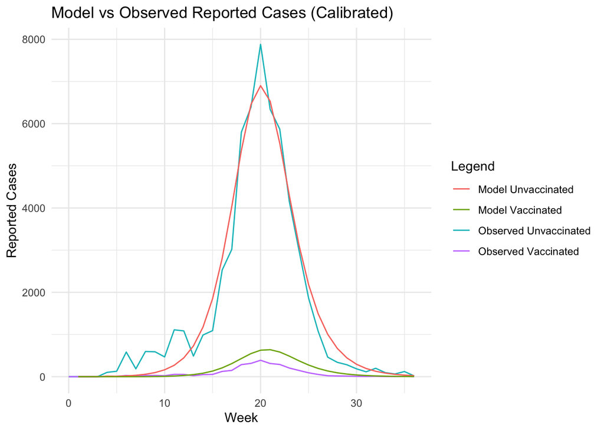

```r
plot_df <- real_data %>%
  left_join(out_df, by = "week")

ggplot(plot_df, aes(x = week)) +
  geom_line(aes(y = unvaccinated_cases, color = "Observed Unvaccinated")) +
  geom_line(aes(y = vaccinated_cases, color = "Observed Vaccinated")) +
  geom_line(aes(y = reported_unvacc, color = "Model Unvaccinated")) +
  geom_line(aes(y = reported_vacc, color = "Model Vaccinated")) +
  labs(title = "Model vs Observed Reported Cases (Calibrated)",
       x = "Week", y = "Reported Cases", color = "Legend") +
  theme_minimal()
```